# LWT Data Exploration

### *Predator Avoidance*

```r
AF_PA_low_human<- low_human %>% filter(Age == "A", Sex == "F", Behavior %in% c("PA"))
head(AF_PA_low_human)
```

```
##  [1] Scan.info          Day                Month              Poop.collected.y.n
##  [5] AM.PM              Weather            Loc.Desc           Scan.time
##  [9] Age                Sex                Strata             Behavior
## [13] Descriptor         Location           ScanID             HumanLevel
## <0 rows> (or 0-length row.names)
```

```r
prop_AF_PA_low_human<- (nrow(AF_PA_low_human)/nrow(AF_low_human))*100
prop_AF_PA_low_human #0
```

```
## [1] 0
```

### *Self Groom*

```r
AF_SG_low_human<- low_human %>% filter(Age == "A", Sex == "F", Behavior %in% c("SG"))
head(AF_SG_low_human)
```

```
##  [1] Scan.info          Day                Month              Poop.collected.y.n
##  [5] AM.PM              Weather            Loc.Desc           Scan.time
##  [9] Age                Sex                Strata             Behavior
## [13] Descriptor         Location           ScanID             HumanLevel
## <0 rows> (or 0-length row.names)
```

```r
prop_AF_SG_low_human<- (nrow(AF_SG_low_human)/nrow(AF_low_human))*100
prop_AF_SG_low_human #0
```

```
## [1] 0
```

### *Threatening*

```r
AF_Th_low_human<- low_human %>% filter(Age == "A", Sex == "F", Behavior %in% c("Th+", "Th-"))
head(AF_Th_low_human)
```

```
##      Scan.info Day Month Poop.collected.y.n AM.PM Weather Loc.Desc Scan.time
## 1 12_June_6:20  12  June                       AM    C LW        F      6:20
##   Age Sex Strata Behavior Descriptor Location ScanID HumanLevel
## 1   A   F     MC      Th+          0        F    280          L
```

```r
prop_AF_Th_low_human<- (nrow(AF_Th_low_human)/nrow(AF_low_human))*100
prop_AF_Th_low_human #0.127
```

```
## [1] 0.1269036
```

```r
#Note: I removed the self-groom behavior from this matrix because the value was 0 for high, med and low category, no self-grooming occurred with adult females

AF_behaviors_table2<- matrix(c(prop_AF_Fe_high_human, prop_AF_Fe_med_human, prop_AF_Fe_low_human, prop_AF_G_high_human, prop_AF_G_med_human, prop_AF_G_low_human, prop_AF_Ag_high_human, prop_AF_Ag_med_human, prop_AF_Ag_low_human, prop_AF_PA_high_human, prop_AF_PA_med_human, prop_AF_PA_low_human, prop_AF_Th_high_human, prop_AF_Th_med_human, prop_AF_Th_low_human), ncol= 3, byrow = TRUE)
colnames(AF_behaviors_table2)<- c("High Human", "Med Human", "Low Human")
rownames(AF_behaviors_table2)<- c("Feeding", "Grooming", "Aggression", "Predator Avoidance", "Threatening")
AF_behaviors_table2<- as.table(AF_behaviors_table2)
AF_behaviors_table2
```

```
##                    High Human  Med Human  Low Human
## Feeding            43.8725490 43.5228332 19.2893401
## Grooming            8.8235294  5.5917987 12.3096447
## Aggression          0.7352941  0.2795899  1.0152284
## Predator Avoidance  0.4901961  0.0000000  0.0000000
## Threatening         0.0000000  0.1863933  0.1269036
```

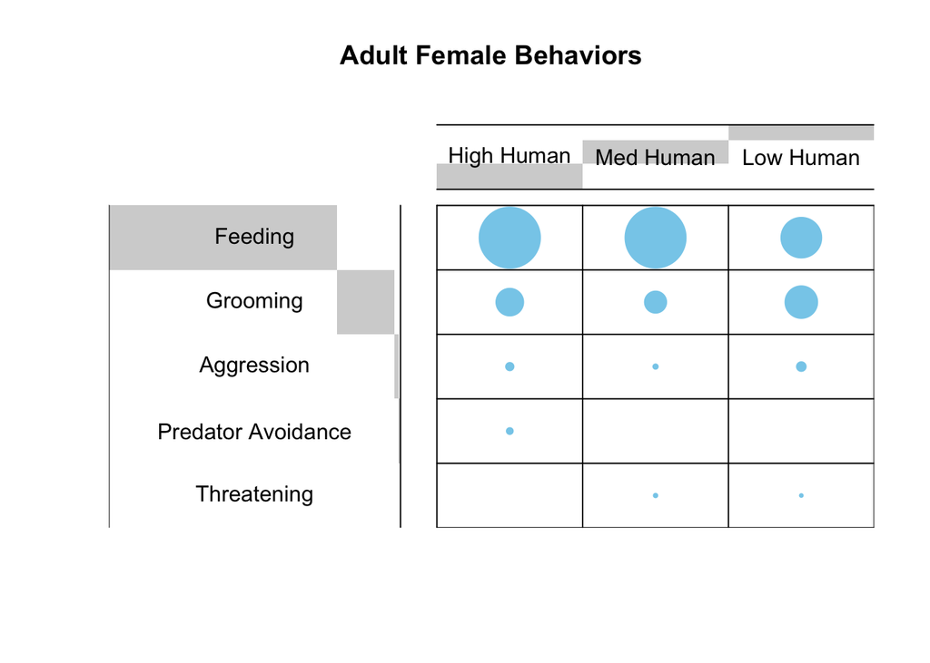

```r
balloonplot(t(AF_behaviors_table2), main ="Adult Female Behaviors", xlab ="", ylab="",
            label = FALSE, show.margins = FALSE)
```

## Running a chi-square test for the high/med/low AF behaviors

```r
AF_chisq2 <- chisq.test(AF_behaviors_table2)
AF_chisq2
```

```
##
##  Pearson's Chi-squared test
##
## data:  AF_behaviors_table2
## X-squared = 11.465, df = 8, p-value = 0.1767
```

```r
AF_chisq2$observed
```

```
##                    High Human  Med Human  Low Human
## Feeding            43.8725490 43.5228332 19.2893401
## Grooming            8.8235294  5.5917987 12.3096447
## Aggression          0.7352941  0.2795899  1.0152284
## Predator Avoidance  0.4901961  0.0000000  0.0000000
## Threatening         0.0000000  0.1863933  0.1269036
```

```r
round(AF_chisq2$expected,2)
```

```
##                    High Human Med Human Low Human
## Feeding                 42.22     38.82     25.64
## Grooming                10.58      9.73      6.42
## Aggression               0.80      0.74      0.49
## Predator Avoidance       0.19      0.18      0.12
## Threatening              0.12      0.11      0.08
```

```r
round(AF_chisq2$residuals, 3) #This shows us our Pearson residuals (Cells with the highest absolute standardized residuals contribute the most to the total Chi-square score)
```

```
##                    High Human Med Human Low Human
## Feeding                 0.254     0.754    -1.254
## Grooming               -0.539    -1.326     2.323
## Aggression             -0.076    -0.534     0.755
## Predator Avoidance      0.672    -0.422    -0.343
## Threatening            -0.352     0.214     0.188
```

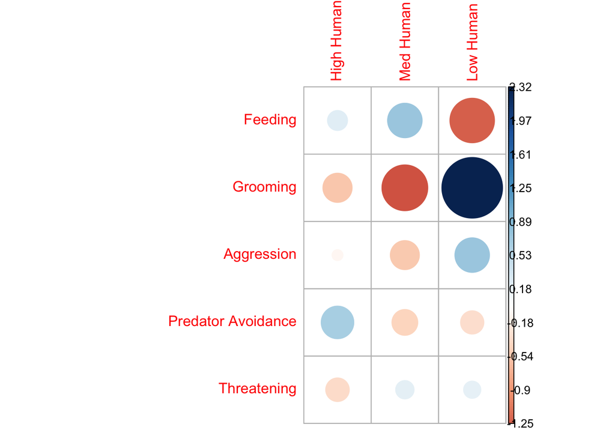

```r
corrplot(AF_chisq2$residuals, is.cor = FALSE) #Allows us to visualize the residuals, blue is positive correlation and red is negative
```

```r
contrib2 <- 100*AF_chisq2$residuals^2/AF_chisq2$statistic #The contribution (in %) of a given cell to the total Chi-square score
round(contrib2, 3)
```

```
##                    High Human Med Human Low Human
## Feeding                 0.562     4.961    13.712
## Grooming                2.536    15.325    47.073
## Aggression              0.050     2.490     4.972
## Predator Avoidance      3.944     1.556     1.028
## Threatening             1.082     0.401     0.309
```

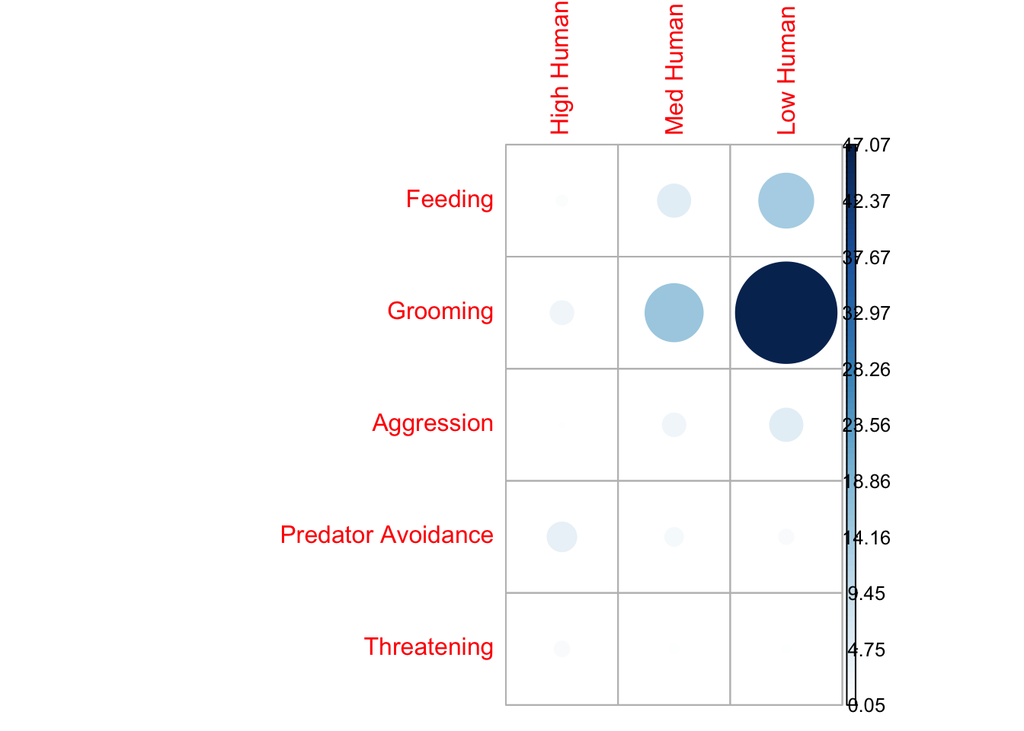

```r
corrplot(contrib2, is.cor = FALSE) #Visualizing the contribution %s
```

## Combining all of my human level dfs into one

```r
humanlevel_ALL<- rbind(high_human, med_human, low_human)
nrow(humanlevel_ALL) #10516
```

```
## [1] 10516
```

```r
nrow(vervets_full) #10517 (header?)
```

```
## [1] 10517
```

```r
unique(humanlevel_ALL$HumanLevel)
```

```
## [1] "H" "M" "L"
```

## Using full_join to combine my human level categories with the food descriptor categories I made… then I make another dataset which removes the NAs from the Food Descriptor column

```r
fulljoinDF<- full_join(humanlevel_ALL, food_desc_ALL, by = c("Day", "Month", "Poop.collected.y.n", "AM.PM", "Weather", "Loc.Desc", "Scan.time", "Age", "Sex", "Strata", "Behavior", "Descriptor", "Location"))
View(fulljoinDF)

fulljoinDF_noNA<- drop_na(fulljoinDF)
nrow(fulljoinDF_noNA)
```

```
## [1] 8252
```

## Plotting the food descriptor categories across the three human levels

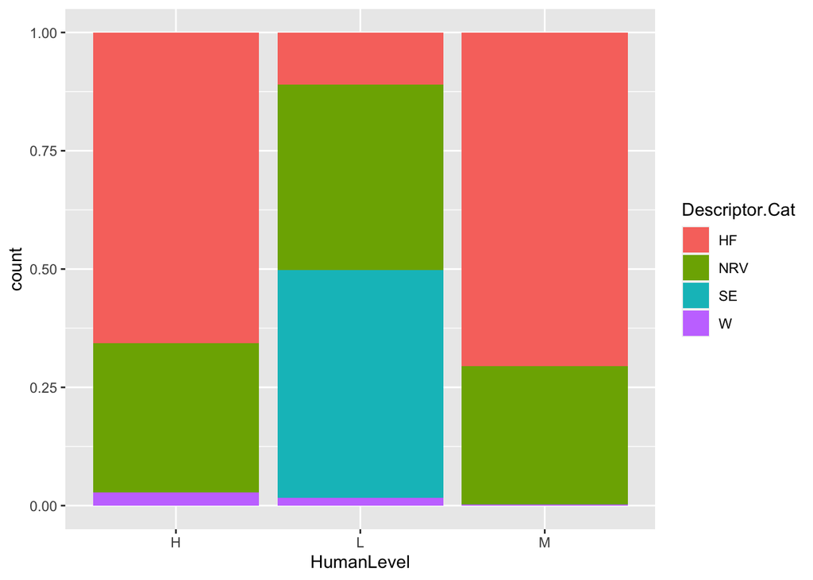

```r
ggplot(data = na.omit(fulljoinDF),aes(x= HumanLevel, fill=Descriptor.Cat, na.rm = TRUE)) +
   geom_bar(position="fill") #There are a lot of NAs in the Descriptor Cat column so this removes them
```

```r
#This plot shows that there are the most HF, "Human Foods" in the high and medium human level locations and spilled enclosure food only in the low level group
```

## Plotting the different age groups across the three human levels, grouped by age

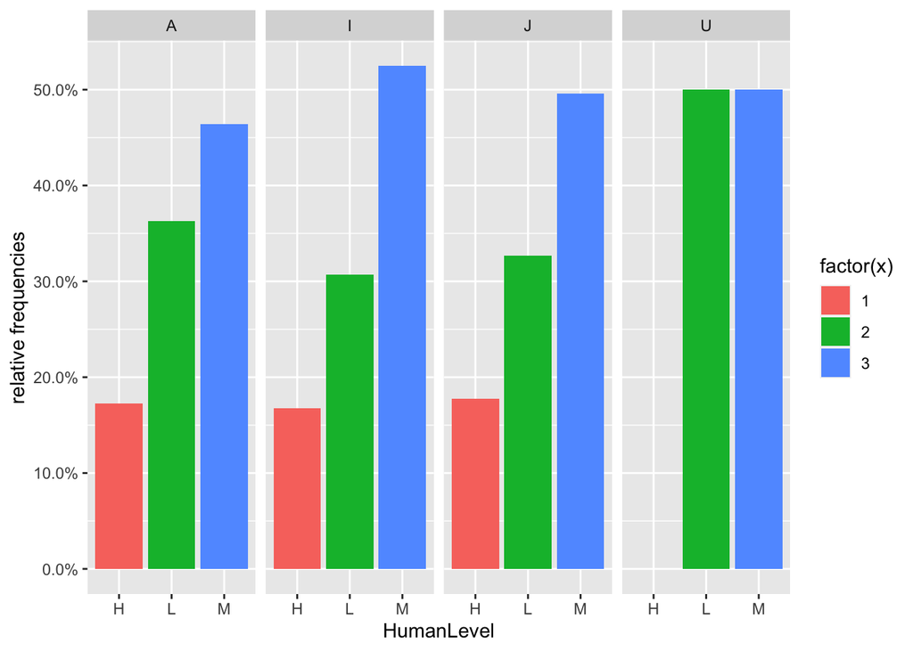

```r
HumanLevel_Age_plot <- ggplot(humanlevel_ALL, aes(HumanLevel, group = Age)) +
          geom_bar(aes(y = ..prop.., fill = factor(..x..)), stat="count") +
          scale_y_continuous(labels=scales::percent) +
          ylab("relative frequencies") +
          facet_grid(~Age)
HumanLevel_Age_plot
```

```r
# This plot shows that the percentage of adult, juvenile, and infant monkeys across the 3 human levels is pretty consistent. Overall, there are the most individuals in the medium human level group and the least in the high human level group.
```

## Plotting the ages/sexs in the three human levels, filled bar format

### *By Age*

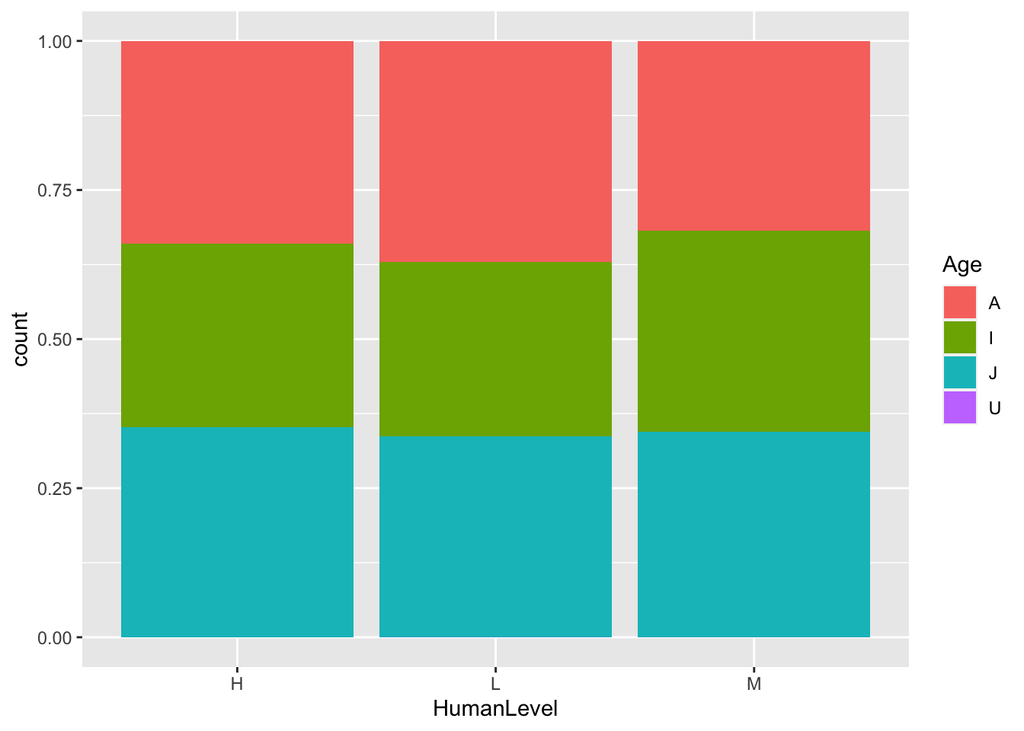

```r
ggplot(data = humanlevel_ALL, aes(x= HumanLevel, fill=Age)) +
   geom_bar(position="fill")
```

### *By Sex*

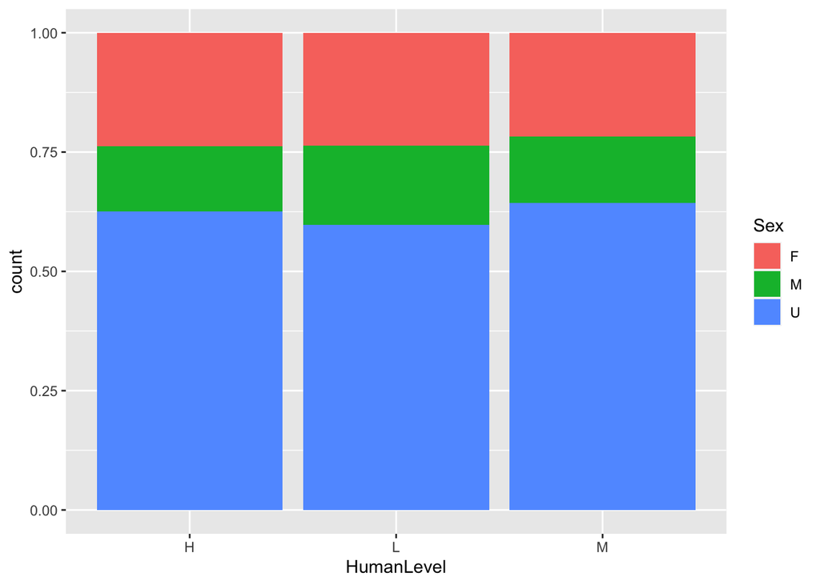

```r
ggplot(data = humanlevel_ALL, aes(x= HumanLevel, fill=Sex)) +
   geom_bar(position="fill") #Lots of unknowns
```

```r
library(lubridate)
HighHum_Fe_DF<- humanlevel_ALL %>% filter(HumanLevel == "H", Behavior %in% c("Fe", "Fo")) #Filtering out only the Fe/Fo behaviors in the High Human location category

HighHum_Fe_DF$Scan.time <- strptime(HighHum_Fe_DF$Scan.time, "%H:%M") #Must use strptime() first b/c this tells the 'strptime' function what format is currently in use, and exports a POSIX-compatible datetime.
HighHum_Fe_DF$Scan.time <- as.POSIXct(HighHum_Fe_DF$Scan.time) #Now you can use the as.POSIXct format; NOTE: this puts in today's current Year-Month-Day into the Scan.time column, I'm not sure how to remove this yet so I'm just going to keep it in for now

HighHum_Fe_6thr9<- with(HighHum_Fe_DF, HighHum_Fe_DF[hour(Scan.time) >= 6 & hour(Scan.time) < 9,]) #Now specifying which time chunk I'd like to look at; 6 through 10
head(HighHum_Fe_6thr9)
```

```
##      Scan.info Day Month Poop.collected.y.n AM.PM Weather Loc.Desc
## 1 11_June_6:10  11  June                  Y    AM   SC LW       HO
## 2 11_June_6:10  11  June                  Y    AM   SC LW       HO
## 3 11_June_6:10  11  June                  Y    AM   SC LW       HO
## 4 11_June_6:20  11  June                  Y    AM   SC LW       HO
## 5 11_June_6:20  11  June                  Y    AM   SC LW       HO
## 6 11_June_6:20  11  June                  Y    AM   SC LW       HO
##             Scan.time Age Sex Strata Behavior Descriptor Location ScanID
## 1 2020-08-07 06:10:00   J   U     MC       Fe        HFg       HO    136
## 2 2020-08-07 06:10:00   I   U      G       Fo        HFg       HO    136
## 3 2020-08-07 06:10:00   A   F      G       Fo        HFg       HO    136
## 4 2020-08-07 06:20:00   A   F    HCS       Fe        HFn       HO    137
## 5 2020-08-07 06:20:00   I   U    HCS       Fe        HFn       HO    137
## 6 2020-08-07 06:20:00   I   U    HCS       Fe        HFn       HO    137
##   HumanLevel
## 1          H
## 2          H
## 3          H
## 4          H
## 5          H
## 6          H
```

```r
HighHum_Fe_9thr12<- with(HighHum_Fe_DF, HighHum_Fe_DF[hour(Scan.time) >= 9 & hour(Scan.time) < 12,])
head(HighHum_Fe_9thr12) #9 through 12
```

```
##        Scan.info Day Month Poop.collected.y.n AM.PM Weather Loc.Desc
## 53  11_June_9:45  11  June                       AM   SC LW    HO Ln
## 54 12_June_10:25  12  June                       AM   LW SC     F RO
## 55 12_June_10:25  12  June                       AM   LW SC     F RO
## 56 12_June_10:30  12  June                       AM   LW SC     F RO
## 57 12_June_10:35  12  June                       AM   LW SC     F RO
## 58 12_June_10:40  12  June                       AM   LW SC     F RO
##              Scan.time Age Sex Strata Behavior Descriptor Location ScanID
## 53 2020-08-07 09:45:00   I   U    HCS       Fe          N       HO    158
## 54 2020-08-07 10:25:00   J   U      G       Fo        HFg       RO    257
## 55 2020-08-07 10:25:00   I   U      G       Fo        HFg       RO    257
## 56 2020-08-07 10:30:00   J   M      G       Fo        HFg       RO    258
## 57 2020-08-07 10:35:00   A   M      G       Fo        HFg       RO    259
## 58 2020-08-07 10:40:00   I   U      G       Fe        HFg       RO    260
##    HumanLevel
## 53          H
## 54          H
## 55          H
## 56          H
## 57          H
## 58          H
```

```r
HighHum_Fe_12thr15<- with(HighHum_Fe_DF, HighHum_Fe_DF[hour(Scan.time) >= 12 & hour(Scan.time) < 15,])
head(HighHum_Fe_12thr15) #12 through 15
```

```
##        Scan.info Day Month Poop.collected.y.n AM.PM Weather Loc.Desc
## 74 13_June_12:10  13  June                       PM   LW SC    Ln HO
## 75 13_June_12:15  13  June                       PM   LW SC    Ln HO
## 76 13_June_12:15  13  June                       PM   LW SC    Ln HO
## 77 13_June_12:15  13  June                       PM   LW SC    Ln HO
## 78 13_June_12:15  13  June                       PM   LW SC    Ln HO
## 79 13_June_12:15  13  June                       PM   LW SC    Ln HO
##              Scan.time Age Sex Strata Behavior Descriptor Location ScanID
## 74 2020-08-07 12:10:00   A   M      G       Fe        HFn       HO    314
## 75 2020-08-07 12:15:00   J   F     MC       Fe        HFg       HO    315
## 76 2020-08-07 12:15:00   A   F     MC       Fe        HFg       HO    315
## 77 2020-08-07 12:15:00   J   U      G       Fo        HFg       HO    315
## 78 2020-08-07 12:15:00   A   F     MC       Fe        HFn       HO    315
## 79 2020-08-07 12:15:00   A   M     MC       Fe        HFn       HO    315
##    HumanLevel
## 74          H
## 75          H
## 76          H
## 77          H
## 78          H
## 79          H
```

```r
HighHum_Fe_15thr18<- with(HighHum_Fe_DF, HighHum_Fe_DF[hour(Scan.time) >= 15 & hour(Scan.time) < 18,])
head(HighHum_Fe_15thr18) #15 through 18
```

```
##         Scan.info Day Month Poop.collected.y.n AM.PM Weather Loc.Desc
## 153 13_June_15:30  13  June                       PM   LW SC    CP RS
## 154 13_June_16:10  13  June                               LW Ln PG PW
## 155 13_June_16:10  13  June                               LW Ln PG PW
## 156 13_June_16:10  13  June                               LW Ln PG PW
## 157 13_June_16:15  13  June                               LW Ln PG PW
## 158 13_June_16:15  13  June                               LW Ln PG PW
##               Scan.time Age Sex Strata Behavior Descriptor Location ScanID
## 153 2020-08-07 15:30:00   J   M      G       Fe         HF       RS    354
## 154 2020-08-07 16:10:00   I   U     Fo       Fo          N       PG    362
## 155 2020-08-07 16:10:00   I   U     Fo       Fo          N       PG    362
## 156 2020-08-07 16:10:00   J   U      G       Fo          N       PG    362
## 157 2020-08-07 16:15:00   I   U      G       Fo        HFg       PG    363
## 158 2020-08-07 16:15:00   I   U      G       Fe        HFg       PG    363
##     HumanLevel
## 153          H
## 154          H
## 155          H
## 156          H
## 157          H
## 158          H
```

## Creating a new column in HighHum_Fe_DF called “Time Block”

```r
#First I have to create a new column called "time.block" in each of my dfs and specify what I want in that column
HighHum_Fe_6thr9$Time.Block<- "6-9"
HighHum_Fe_9thr12$Time.Block<- "9-12"
HighHum_Fe_12thr15$Time.Block<- "12-15"
HighHum_Fe_15thr18$Time.Block<- "15-18"

#Now I combine all of my dfs into one so that I can plot it by the Time.Block Column
HighHum_Fe_ALL<- rbind(HighHum_Fe_6thr9, HighHum_Fe_9thr12, HighHum_Fe_12thr15, HighHum_Fe_15thr18)
unique(HighHum_Fe_ALL$Time.Block)
```

```
## [1] "6-9"   "9-12"  "12-15" "15-18"
```

## Plotting the number of feeding/foraging behaviors across the 4 time blocks

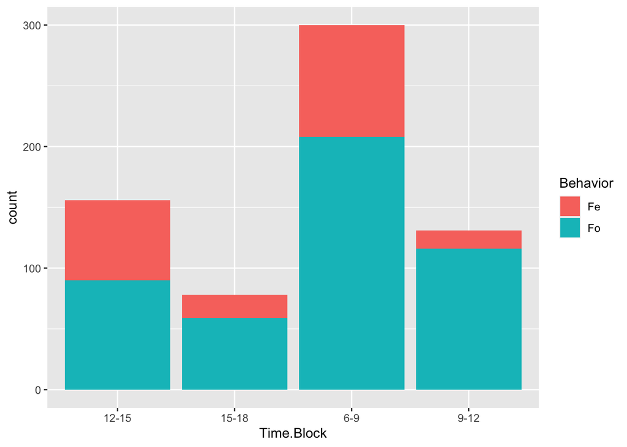

```r
TimeBlock_Fe_plot<- ggplot(data = HighHum_Fe_ALL, aes(x= Time.Block, fill=Behavior)) +
   geom_bar((aes(fill = Behavior)))
TimeBlock_Fe_plot
```

```r
#From this plot, we can see that there are the highest number of feeding and foraging behaviors during the 6-9am time block and the second highest during 12-15. Feeding and foraging occured the least during the 15-18 time block.
```